# Bass Model Analysis: Samsung Micro RGB TV

Albert Hakobyan

01-03-2026

## Libraries

```r
libs <- c('ggplot2', 'ggpubr', 'knitr', 'diffusion')
load_libraries <- function(libs) {
  new_libs <- libs[!(libs %in% installed.packages()[, "Package"])]
  if (length(new_libs) > 0) { install.packages(new_libs) }
  lapply(libs, library, character.only = TRUE)}
load_libraries(libs)
```

## Defining Bass Model Functions

Following the lecture formulas:
$$f(t) =
\frac{(p+q)^2}{p} \cdot \frac{e^{-(p+q)t}}{\left[1 + \frac{q}{p}
e^{-(p+q)t}\right]^2}$$
$$F(t) =
\frac{1 - e^{-(p+q)t}}{1 + \frac{q}{p} e^{-(p+q)t}}$$

```r
bass.f <- function(t, p, q) {
  ((p + q)^2 / p) * exp(-(p + q) * t) / (1 + (q / p) * exp(-(p + q) * t))^2
  }

bass.F <- function(t, p, q) {
  (1 - exp(-(p + q) * t)) /(1 + (q / p) * exp(-(p + q) * t))
  }
```

## Part 3 — Historical Data: LG OLED TV Shipments (2013–2025)

```r
oled_data <- read.csv("./data/OLED_TV_Global_Annual_Shipments_2013_2025.csv")
names(oled_data) <- c("year", "sales", "cum_sales", "source")
oled_data$t <- 1:nrow(oled_data)

kable(oled_data[, c("year", "sales", "cum_sales", "t")],
      caption = "Global OLED TV Annual Shipments (Million Units)",
      col.names = c("Year", "Annual Shipments (M)", "Cumulative (M)", "t"))
```

Global OLED TV Annual Shipments (Million Units)

| Year | Annual Shipments (M) | Cumulative (M) | t |
| --- | --- | --- | --- |
| 2013 | 0.005 | 0.005 | 1 |
| 2014 | 0.077 | 0.082 | 2 |
| 2015 | 0.400 | 0.482 | 3 |
| 2016 | 0.720 | 1.202 | 4 |
| 2017 | 1.470 | 2.672 | 5 |
| 2018 | 2.510 | 5.182 | 6 |
| 2019 | 3.000 | 8.182 | 7 |
| 2020 | 3.940 | 12.122 | 8 |
| 2021 | 6.700 | 18.822 | 9 |
| 2022 | 6.670 | 25.492 | 10 |
| 2023 | 5.440 | 30.932 | 11 |
| 2024 | 6.070 | 37.002 | 12 |
| 2025 | 6.430 | 43.432 | 13 |

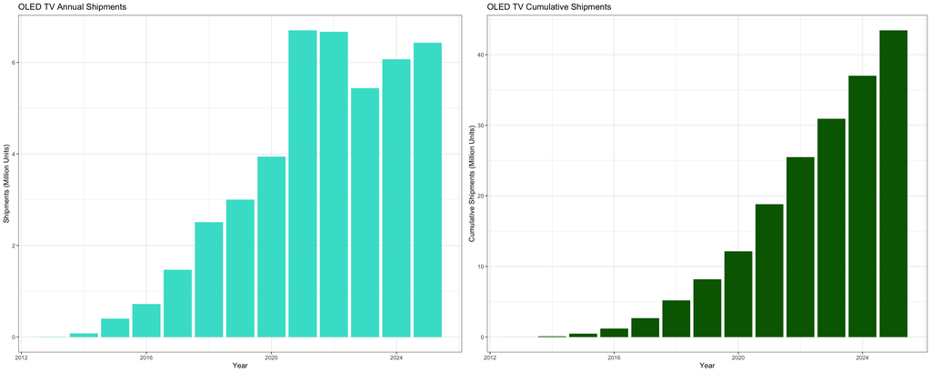

```r
p1 <- ggplot(oled_data, aes(x = year, y = sales)) +
  geom_bar(stat = 'identity', fill = 'turquoise') +
  labs(title = 'OLED TV Annual Shipments',
       x = 'Year', y = 'Shipments (Million Units)') +
  theme_bw()

p2 <- ggplot(oled_data, aes(x = year, y = cum_sales)) +
  geom_bar(stat = 'identity', fill = 'darkgreen') +
  labs(title = 'OLED TV Cumulative Shipments',
       x = 'Year', y = 'Cumulative Shipments (Million Units)') +
  theme_bw()

ggarrange(p1, p2, ncol = 2)
```

> The 2022–2023 deviation from the fitted curve reflects macroeconomic shocks (European inflation, energy costs) and competitive pressure from MiniLED, which are exogenous factors not captured by the Bass diffusion framework.

## Part 4 — Estimating Bass Model parameters

### Method 1: Non-linear Least Squares (`nls`)

Using the closed-form Bass equation: $a(t) = m \cdot f(t)$

```r
sales <- oled_data$sales
t <- 1:length(sales)

bass_m <- nls(sales ~ m * (((p + q)^2 / p) * exp(-(p + q) * t)) / (1 + (q / p) * exp(-(p + q) * t))^2,
              start = c(list(m = sum(sales), p = 0.02, q = 0.4)))

summary(bass_m)
```

```
##
## Formula: sales ~ m * (((p + q)^2/p) * exp(-(p + q) * t))/(1 + (q/p) *
##     exp(-(p + q) * t))^2
##
## Parameters:
##    Estimate Std. Error t value Pr(>|t|)
## m 59.718197   5.877942  10.160 1.37e-06 ***
## p  0.003160   0.001163   2.718   0.0216 *
## q  0.442787   0.053053   8.346 8.11e-06 ***
## ---
## Signif. codes:  0 '***' 0.001 '**' 0.01 '*' 0.05 '.' 0.1 ' ' 1
##
## Residual standard error: 0.6894 on 10 degrees of freedom
##
## Number of iterations to convergence: 11
## Achieved convergence tolerance: 7.208e-06
```

```r
m_nls <- round(coef(bass_m)["m"], 4)
p_nls <- round(coef(bass_m)["p"], 4)
q_nls <- round(coef(bass_m)["q"], 4)

cat("NLS Estimates:\n")
```

```
## NLS Estimates:
```

```r
cat("  m (market potential):", m_nls, "million units\n")
```

```
##   m (market potential): 59.7182 million units
```

```r
cat("  p (innovation coeff):", p_nls, "\n")
```

```
##   p (innovation coeff): 0.0032
```

```r
cat("  q (imitation coeff): ", q_nls, "\n")
```

```
##   q (imitation coeff):  0.4428
```

### Method 2: Using the `diffusion` package’s tools

The `diffusion` package estimates p, q, m as suggested by Bass.

```r
diff_m <- diffusion(sales)
diff_m
```

```
## bass model
##
## Parameters:
##   Estimate p-value
## m  64.0267      NA
## p   0.0041      NA
## q   0.4085      NA
##
## sigma: 0.6566
```

```r
m_diff <- round(diff_m$w, 4)[1]
p_diff <- round(diff_m$w, 4)[2]
q_diff <- round(diff_m$w, 4)[3]


cat("\nDiffusion Package Estimates:\n")
```

```
##
## Diffusion Package Estimates:
```

```r
cat("  m (market potential):", m_diff, "million units\n")
```

```
##   m (market potential): 64.0267 million units
```

```r
cat("  p (innovation coeff):", p_diff, "\n")
```

```
##   p (innovation coeff): 0.0041
```

```r
cat("  q (imitation coeff): ", q_diff)
```

```
##   q (imitation coeff):  0.4085
```

### Comparing both methods

```r
comparison <- data.frame(
  Parameter = c("p (innovation)", "q (imitation)", "m (market potential, M units)"),
  NLS = c(p_nls, q_nls, m_nls),
  Diffusion = c(p_diff, q_diff, m_diff)
)
kable(comparison, caption = "Parameter Estimates Comparison")
```

Parameter Estimates Comparison

|  | Parameter | NLS | Diffusion |
| --- | --- | --- | --- |
| p | p (innovation) | 0.0032 | 0.0041 |
| q | q (imitation) | 0.4428 | 0.4085 |
| m | m (market potential, M units) | 59.7182 | 64.0267 |

```r
# Diffusion = c(p_diff, q_diff, m_diff)
#p_est <- as.numeric(0.0015) # this is my approximation after tweaking this parameter up and down > But I prefer the NLS estimate
#q_est <- as.numeric(0.5) # this is my approximation after tweaking this parameter up and down > But I prefer the NLS estimate
#m_est <- as.numeric(60)
#
#p_est <- as.numeric(p_diff)
#q_est <- as.numeric(q_diff)
#m_est <- as.numeric(m_diff)
#
#


p_est <- as.numeric(p_nls)
q_est <- as.numeric(q_nls)
m_est <- as.numeric(m_nls)
```

### Visualizing the Fitted Model vs. Actual Data

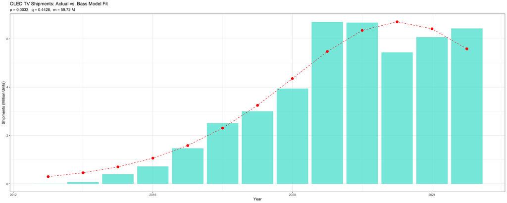

```r
oled_data$pred_sales <- bass.f(1:nrow(oled_data), p = p_est, q = q_est) * m_est

ggplot(oled_data, aes(x = year, y = sales)) +
  geom_bar(stat = 'identity', fill = 'turquoise', alpha = 0.7) +
  geom_point(aes(y = pred_sales), color = 'red', size = 3) +
  geom_line(aes(y = pred_sales), color = 'red', linetype = 'dashed') +
  labs(title = 'OLED TV Shipments: Actual vs. Bass Model Fit',
       subtitle = paste0('p = ', p_est, ',  q = ', q_est, ',  m = ', round(m_est, 2), ' M'),
       x = 'Year', y = 'Shipments (Million Units)') +
  theme_bw()
```

### Plots of f(t) and F(t) theoretical curves using estimated parameters

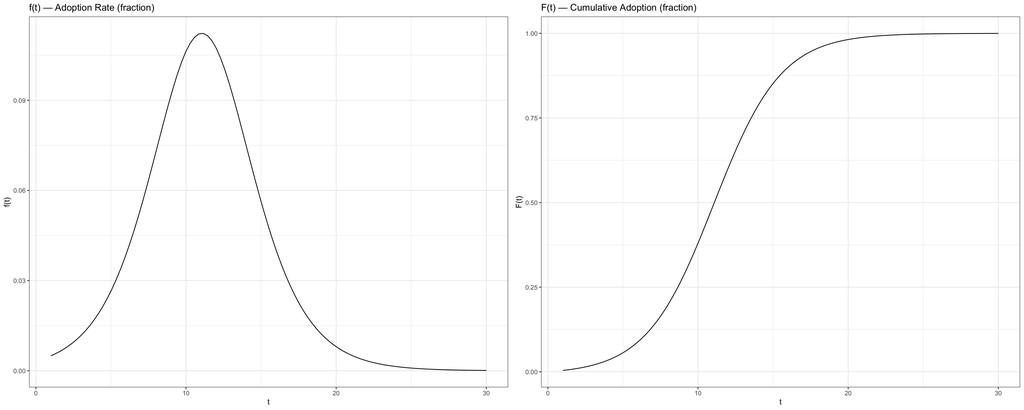

```r
# f(t) and F(t) theoretical curves using estimated parameters
ft_plot <- ggplot(data.frame(t = c(1, 30)), aes(t)) +
  stat_function(fun = bass.f, args = c(p = p_est, q = q_est)) +
  labs(title = 'f(t) — Adoption Rate (fraction)', x = 't', y = 'f(t)') +
  theme_bw()

Ft_plot <- ggplot(data.frame(t = c(1, 30)), aes(t)) +
  stat_function(fun = bass.F, args = c(p = p_est, q = q_est)) +
  labs(title = 'F(t) — Cumulative Adoption (fraction)', x = 't', y = 'F(t)') +
  theme_bw()

ggarrange(ft_plot, Ft_plot, ncol = 2)
```

### Time to Peak Sales

$$t^* = \frac{\ln(q/p)}{p +
q}$$

```r
t_star <- log(q_est / p_est) / (p_est + q_est)
peak_year_oled <- 2013 + t_star - 1  #t=1 corresponds to 2013

cat("Predicted peak period (t*):", round(t_star, 2), "\n")
```

```
## Predicted peak period (t*): 11.05
```

```r
cat("Corresponding calendar year:", round(peak_year_oled, 1), "\n")
```

```
## Corresponding calendar year: 2023.1
```

```r
cat("Actual peak year in data:  ", oled_data$year[which.max(oled_data$sales)], "\n")
```

```
## Actual peak year in data:   2021
```

## Task 5, 6, 7 — Predict the Diffusion of Samsung Micro RGB TV

### Scope: Global Diffusion

I analyze diffusion worldwide because the look-alike product data (LG OLED TV) is global shipment data. Samsung also launches Micro RGB as a global product, so applying global p and q is consistent with that.

### Estimating Market Potential (m) for Samsung Micro RGB TV

The LG OLED TV data gives us estimated p and q. For Samsung Micro RGB TV, we need our own estimate of **m** (market potential). Here is the Fermi estimation (same estimation is also done within the other report PDF file in the ./report directory):

```r
# --- Fermi Estimation for Samsung Micro RGB TV Market Potential ---
#
# The global TV market ships about 200-230M units/year (TrendForce 2023; Counterpoint 2025).
# Of those, roughly 8-10% fall in the premium segment above $1,500 — around 18M units/year.
# Our NLS fit estimates OLED TV's lifetime market potential at ~60M cumulative units.
#
# Samsung Micro RGB TV targets the same premium segment, but must probably lead to steeper upward trend:
# it launched at $29,999 (about 2x the first LG OLED's $15,000 in 2013), Samsung is the
# sole manufacturer (vs. 20+ OLED TV brands by 2022), and it enters a market where OLED
# and MiniLED are already mature competitors and the customers' perceived benefit is not going to be the same as for the OLEDs (my oppinion).
#
# So I scale OLED's m down by 0.65 to account for all of the above-mentioned; it is a number which adds my personal bias.
# Samsung is an established brand for the ultra-premium segment so this coefficient may fluctuate as well: 0.60-0.75
#
# Sources:
#   TrendForce (Nov 2023) — ~197M TV shipments: https://www.trendforce.com/presscenter/news/20231128-11931.html
#   Counterpoint/Omdia (2025) — 230M units in 2024: https://displaydaily.com/tv-market-recovering-getting-bigger-brighter-better/
#   LG OLED launch price ($15K, 2013): https://www.oled-info.com/lgs-oled-tv-will-arrive-uk-july-2013-9999-15000
#   20+ OLED TV brands by 2022: https://www.lg.com/global/newsroom/lg-story/beyond-news/lg-oled-tv-a-decade-at-the-top-and-no-sign-of-slowing-down/

m_micro_rgb <- m_est * 0.65
cat("Estimated m for Samsung Micro RGB TV:", round(m_micro_rgb, 1), "million units\n")
```

```
## Estimated m for Samsung Micro RGB TV: 38.8 million units
```

```r
cat("(Based on OLED TV look-alike diffusion potential, scaled by 0.65)\n")
```

```
## (Based on OLED TV look-alike diffusion potential, scaled by 0.65)
```

### Predicted Diffusion Curve for Samsung Micro RGB TV

Samsung Micro RGB TV launched in **2025** (t = 1).

```r
# Prediction horizon: 2025 to 2040 (15 years)
forecast_years <- 2025:2040
t_forecast <- 1:length(forecast_years)

# Predicted annual adoptions
pred_annual <- bass.f(t_forecast, p = p_est, q = q_est) * m_micro_rgb

# Predicted cumulative adoptions
pred_cumulative <- bass.F(t_forecast, p = p_est, q = q_est) * m_micro_rgb

micro_rgb_forecast <- data.frame(year = forecast_years,
                                 t = t_forecast,
                                 predicted_annual = round(pred_annual, 4),
                                 predicted_cumulative = round(pred_cumulative, 4))

kable(micro_rgb_forecast,
      caption = "Predicted Samsung Micro RGB TV Diffusion (Million Units)",
      col.names = c("Year", "t", "Annual Adoptions (M)", "Cumulative Adoptions (M)"))
```

Predicted Samsung Micro RGB TV Diffusion (Million Units)

| Year | t | Annual Adoptions (M) | Cumulative Adoptions (M) |
| --- | --- | --- | --- |
| 2025 | 1 | 0.1925 | 0.1559 |
| 2026 | 2 | 0.2969 | 0.3969 |
| 2027 | 3 | 0.4549 | 0.7675 |
| 2028 | 4 | 0.6896 | 1.3323 |
| 2029 | 5 | 1.0290 | 2.1816 |
| 2030 | 6 | 1.4993 | 3.4340 |
| 2031 | 7 | 2.1105 | 5.2277 |
| 2032 | 8 | 2.8307 | 7.6922 |
| 2033 | 9 | 3.5591 | 10.8927 |
| 2034 | 10 | 4.1272 | 14.7573 |
| 2035 | 11 | 4.3587 | 19.0339 |
| 2036 | 12 | 4.1709 | 23.3331 |
| 2037 | 13 | 3.6313 | 27.2572 |
| 2038 | 14 | 2.9111 | 30.5355 |
| 2039 | 15 | 2.1839 | 33.0779 |
| 2040 | 16 | 1.5583 | 34.9380 |

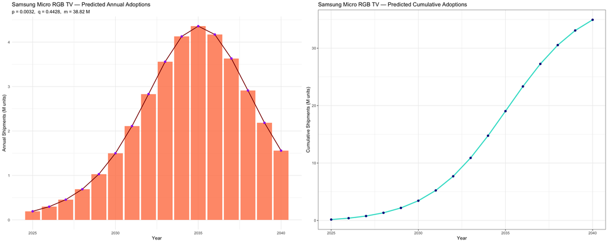

```r
p_annual <- ggplot(micro_rgb_forecast, aes(x = year, y = predicted_annual)) +
  geom_bar(stat = 'identity', fill = 'coral', alpha = 0.8) +
  geom_line(color = 'darkred', linewidth = 0.8) +
  geom_point(color = 'purple', size = 2) +
  labs(title = 'Samsung Micro RGB TV — Predicted Annual Adoptions',
       subtitle = paste0('p = ', p_est, ',  q = ', q_est, ',  m = ', round(m_micro_rgb, 2), ' M'),
       x = 'Year', y = 'Annual Shipments (M units)') +
  theme_minimal()

p_cum <- ggplot(micro_rgb_forecast, aes(x = year, y = predicted_cumulative)) +
  geom_line(color = 'turquoise', linewidth = 1.2) +
  geom_point(color = 'darkblue', size = 2) +
  labs(title = 'Samsung Micro RGB TV — Predicted Cumulative Adoptions',
       x = 'Year', y = 'Cumulative Shipments (M units)') +
  theme_bw()

ggarrange(p_annual, p_cum, ncol = 2)
```

### Peak sales timing for Samsung Micro RGB TV

```r
t_star_micro <- log(q_est / p_est) / (p_est + q_est)
peak_year_micro <- 2025 + t_star_micro

cat("Predicted peak period (t*):", round(t_star_micro, 2), "years after launch\n")
```

```
## Predicted peak period (t*): 11.05 years after launch
```

```r
cat("Predicted peak calendar year:", round(peak_year_micro, 1), "\n")
```

[output not shown]

```r
cat("Predicted peak annual shipments:",
    round(bass.f(t_star_micro, p = p_est, q = q_est) * m_micro_rgb, 2), "million units")
```

```
## Predicted peak annual shipments: 4.36 million units
```

## Part 7 — Estimating the Number of Adopters by Period

```r
# Computing innovators vs imitators at each time period
# From the Bass equation:
#   Total adopters at t:      a(t) = m * f(t)
#   Innovator component:      p * [m - A(t-1)]
#   Imitator component:       q * [A(t-1)/m] * [m - A(t-1)]

adopters <- data.frame(year = forecast_years,
                        t = t_forecast,
                        annual_total = pred_annual,
                        cumulative = pred_cumulative)

# Computing innovator and imitator portions
adopters$remaining <- m_micro_rgb - c(0, adopters$cumulative[-nrow(adopters)])
adopters$cum_prev  <- c(0, adopters$cumulative[-nrow(adopters)])

adopters$innovators <- p_est * adopters$remaining
adopters$imitators  <- q_est * (adopters$cum_prev / m_micro_rgb) * adopters$remaining

kable(adopters[, c("year", "annual_total", "innovators", "imitators", "cumulative")],
      digits = 4,
      caption = "Adopters by Period: Innovators vs. Imitators (Million Units)",
      col.names = c("Year", "Total Adopters (M)", "Innovators (M)",
                     "Imitators (M)", "Cumulative (M)"))
```

Adopters by Period: Innovators vs. Imitators (Million Units)

| Year | Total Adopters (M) | Innovators (M) | Imitators (M) | Cumulative (M) |
| --- | --- | --- | --- | --- |
| 2025 | 0.1925 | 0.1242 | 0.0000 | 0.1559 |
| 2026 | 0.2969 | 0.1237 | 0.0688 | 0.3969 |
| 2027 | 0.4549 | 0.1229 | 0.1740 | 0.7675 |
| 2028 | 0.6896 | 0.1218 | 0.3331 | 1.3323 |
| 2029 | 1.0290 | 0.1200 | 0.5697 | 2.1816 |
| 2030 | 1.4993 | 0.1172 | 0.9117 | 3.4340 |
| 2031 | 2.1105 | 0.1132 | 1.3861 | 5.2277 |
| 2032 | 2.8307 | 0.1075 | 2.0031 | 7.6922 |
| 2033 | 3.5591 | 0.0996 | 2.7311 | 10.8927 |
| 2034 | 4.1272 | 0.0894 | 3.4698 | 14.7573 |
| 2035 | 4.3587 | 0.0770 | 4.0502 | 19.0339 |
| 2036 | 4.1709 | 0.0633 | 4.2954 | 23.3331 |
| 2037 | 3.6313 | 0.0495 | 4.1213 | 27.2572 |
| 2038 | 2.9111 | 0.0370 | 3.5943 | 30.5355 |
| 2039 | 2.1839 | 0.0265 | 2.8846 | 33.0779 |
| 2040 | 1.5583 | 0.0184 | 2.1655 | 34.9380 |

## Summary

```r
summary_df <- data.frame(
  Item = c("Innovation (p)", "Imitation (q)",
           "Market Potential (m, M units)",
           "Predicted Peak Year (Samsung Micro RGB)",
           "Peak Annual Shipments (M units)",
           "Scope"),
  Value = c(p_est, q_est,
            round(m_micro_rgb, 2),
            round(peak_year_micro, 1),
            round(bass.f(t_star_micro, p = p_est, q = q_est) * m_micro_rgb, 2),
            "Global")
)
kable(summary_df, caption = "Bass Model Summary for Samsung Micro RGB TV")
```

Bass Model Summary for Samsung Micro RGB TV

[output not shown]